# Less Volume, More Creativity – Introducing R to Beginners

Randall Pruim and Nicholas J Horton

eCOTS – 17 May 2016

# How to play along from home

- You can use your own R, but make sure `mosaic` is installed from CRAN (or github)

```r
# install from CRAN
install.packages("mosaic")
```

- You can use a temporary RStudio server account
  - get username and password at http://tinyurl.com/ecots-rstudio
- Be sure to attach the `mosaic` package

```r
require(mosaic)
```

- Slides are available at http://tinyurl.com/mosaic-ecots2016

# Outline

- **Introduction to Less Volume, More Creativity Approach**
- **The most important template**
- A few other things
- Simulation-based inference

# Introduction

# The mosaic team

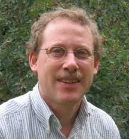

Danny Kaplan  
Macalester

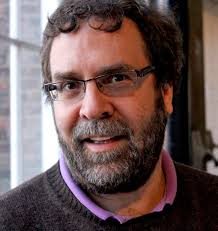

Nick Horton  
Amherst

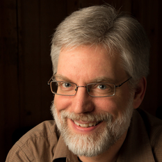

Randy Pruim  
Calvin

[figure not shown]

# Less Volume, More Creativity

Aim for an R toolkit that is

- **small**: fewer commands/templates is better
- **coherent**: commands should be as similar as possible
- **powerful**: can do what needs doing

Perfection is achieved, not when there is nothing more to add, but when there is nothing left to take away.  
— Antoine de Saint-Exupery (writer, poet, pioneering aviator)

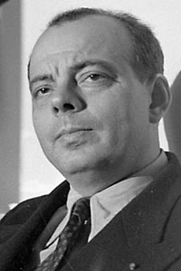

# The mosaic package

The `mosaic` package facilitates a Less Volume, More Creativity approach.

- available via CRAN and github (ProjectMOSAIC/mosaic)
- builds on things in `lattice` and other core R packages

### Main parts of the package

- expanded support for the “formula template” (main topic today)
- simplified graphics
- support for simulation-based inference with `do()`
- some odds and ends (mostly driven by first and second course)

# The Minimal R Exercise

**List** every R command used throughout a course

**Organize** by syntactic similarity and by purpose

**Scratch** everything you could have done without

**Replace** dissimilar tools with more similar tools

**Aim** for a set of commands that is

- **small**: fewer is better
- **coherent**: commands should be as similar as possible
- **powerful**: can do what needs doing

**Result:** [Minimal R for Intro Stats](https://github.com/ProjectMOSAIC/mosaic/blob/master/vignettes/MinimalR.pdf)

# A few R details

### R is case sensitive

- many students are *not* case sensitive

### Arrows and Tab

- up/down arrows scroll through history
- TAB completion can simplify typing

### If all else fails, try ESC

- If you see a + prompt, it means R is waiting for more input
- If this is unintentional, you probably have a typo
- ESC will get you back to the command prompt

# How to play along from home

- You can use your own R, but make sure `mosaic` is installed from CRAN (or github)

```r
# install from CRAN
install.packages("mosaic")
```

- You can use a temporary RStudio server account
  - get username and password at http://tinyurl.com/ecots-rstudio
- Be sure to attach the `mosaic` package

```r
require(mosaic)
```

- Slides are available at http://tinyurl.com/mosaic-ecots2016

# The most important template

# The Most Important Template

## **goal ( y ~ x , data = mydata )**

# The Most Important Template

## **goal ( y ~ x , data = mydata )**

# The Most Important Template

## **goal ( y ~ x , data = mydata , …)**

### Other versions:

```r
# simpler version
goal( ~ x, data = mydata )
# fancier version
goal( y ~ x | z , data = mydata )
# unified version
goal( formula , data = mydata )
```

# 2 Questions

## **goal ( y ~ x , data = mydata )**

### What do you want R to do? (goal)

### What must R know to do that?

# 2 Questions

## **goal ( y ~ x , data = mydata )**

### What do you want R to do? (goal)

- This determines the function to use

### What must R know to do that?

- This determines the inputs to the function
- Must identify the variables and data frame

# How do we make this plot?

### What is the Goal?

### What does R need to know?

# How do we make this plot?

### What is the Goal?

- a scatter plot

### What does R need to know?

- which variable goes where
- which data set

# How do we tell R to make this plot?

### What is the Goal?

- a scatter plot (`xyplot()`)

### What does R need to know?

- which variable goes where (`births ~ date`)
- which data set (`data = Births78`)
  - use `?Births78` for documentation

# How do we make this plot?

## **goal ( y ~ x , data = mydata )**

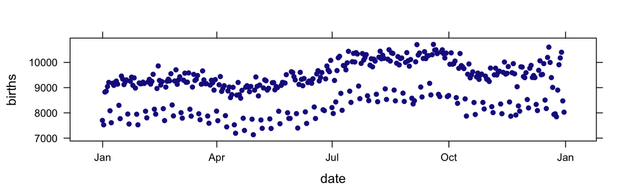

```r
xyplot(births ~ date, data = Births78)
```

# What changes for this plot?

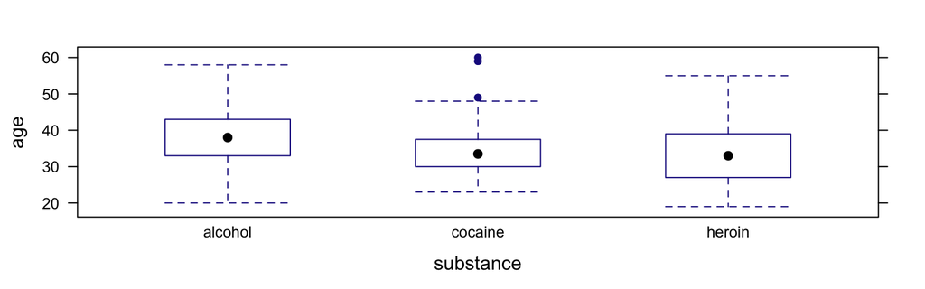

### Two Questions?

# What changes for this plot?

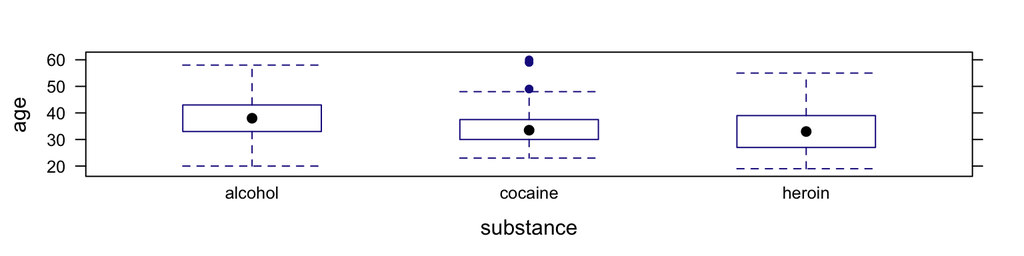

1. Command: `bwplot()`
2. The data: `HELPrct`
- Variables: `age`, `substance`
- use `?HELPrct` for info about data

# Comparing our first two plots

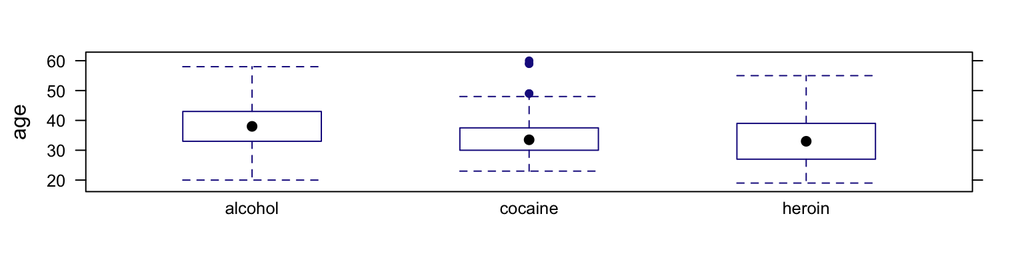

```r
bwplot( age ~ substance, data = HELPrct)
```

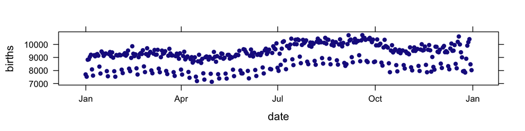

```r
xyplot( births ~ date, data = Births78)
```

# How about this one?

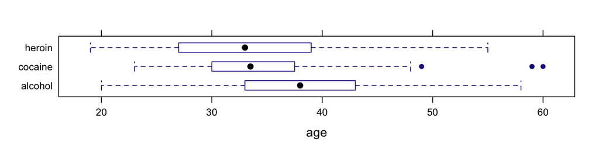

1. Command: `bwplot()`
2. The data: `HELPrct`
- Variables: `age`, `substance`
- use `?HELPrct` for info about data

# Comparing two boxplots

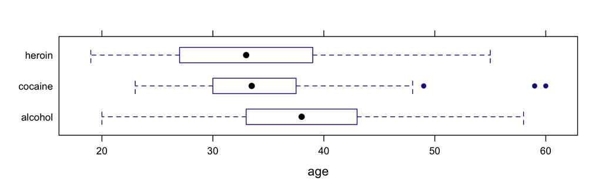

```r
bwplot(substance ~ age, data = HELPrct)
```

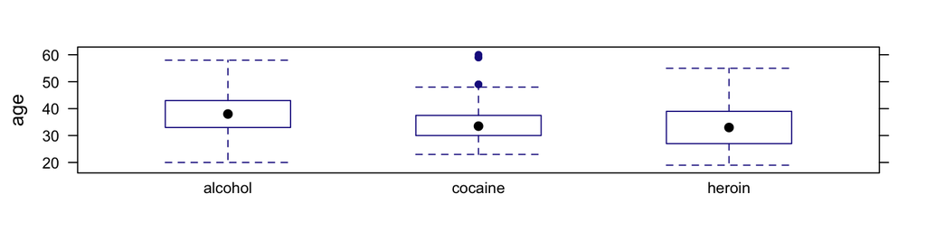

```r
bwplot(age ~ substance, data = HELPrct)
```

# Graphical Summaries: One Variable

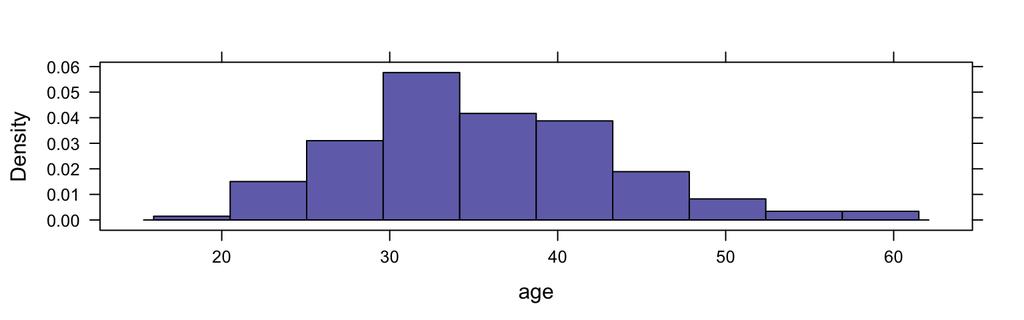

```r
histogram( ~ age, data = HELPrct)
```

Note: When there is **one variable** it is on the **right side** of the formula.

# Graphical Summaries: Overview

### One Variable

```r
  histogram( ~age, data = HELPrct )
densityplot( ~age, data = HELPrct )
     bwplot( ~age, data = HELPrct )
     qqmath( ~age, data = HELPrct )
freqpolygon( ~age, data = HELPrct )
   bargraph( ~sex, data = HELPrct )
```

### Two Variables

```r
xyplot(  i1 ~ age,       data = HELPrct )
bwplot( age ~ substance, data = HELPrct )
bwplot( substance ~ age, data = HELPrct )
```

- **i1** average number of drinks (standard units) consumed per day in the past 30 days (measured at baseline)

# The Graphics Template

### One variable

### **plotname ( ~ x , data = mydata , …)**

- `histogram()`, `qqmath()`, `densityplot()`, `freqpolygon()`, `bargraph()`

### Two Variables

### **plotname ( y ~ x , data = mydata , …)**

- `xyplot()`, `bwplot()`

# groups and panels

- Add `groups =`group to overlay.
- Use `y ~ x | z` to create multipanel plots.

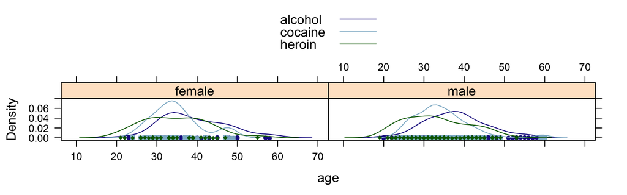

```r
densityplot( ~ age | sex, data = HELPrct,
               groups = substance,  auto.key = TRUE)
```

# Bells & Whistles

- titles
- axis labels
- colors
- sizes
- transparency
- etc, etc.

My approach:

- Let the students ask, or
- let the data analysis drive
- `mplot()`

# Bells and Whistles

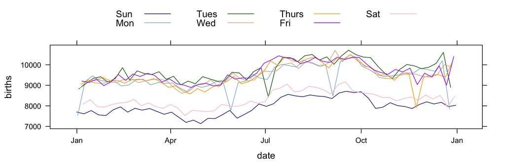

```r
xyplot(births ~ date, data = Births78, groups = wday,
  type = 'l',
  auto.key = list(columns = 4, lines = TRUE, points = FALSE),
  par.settings = list(superpose.line = list( lty = 1 ) ))
```

# Numerical Summaries: One Variable

Big idea: Replace plot name with summary name

- Nothing else changes

```
## [1] 35.65
```

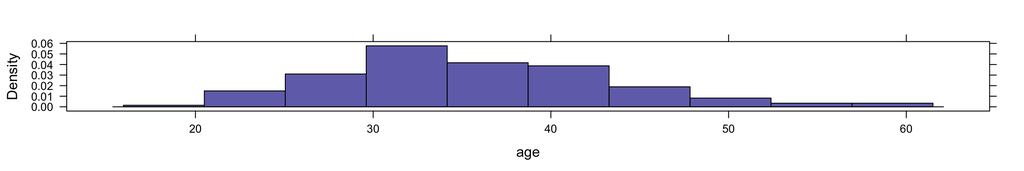

```r
histogram( ~ age, data = HELPrct )
     mean( ~ age, data = HELPrct )
```

# Other Summaries

The mosaic package includes formula aware versions of `mean()`, `sd()`, `var()`, `min()`, `max()`, `sum()`, `IQR()`, …

Also provides `favstats()` to compute our favorites.

```r
favstats( ~ age, data = HELPrct )
```

```
##  min Q1 median Q3 max  mean   sd   n missing
##   19 30     35 40  60 35.65 7.71 453       0
```

# Tallying

```r
tally( ~ sex, data = HELPrct)
```

```
##
## female   male
##    107    346
```

```r
tally( ~ substance, data = HELPrct)
```

```
##
## alcohol cocaine  heroin
##     177     152     124
```

# Numerical Summaries: Two Variables

Three ways to create a plot with two variables. All three can be used to get corresponding numerical summaries.

```r
     bwplot(age ~ substance, data = HELPrct)
         sd(age ~ substance, data = HELPrct)

  histogram( ~ age | substance, data = HELPrct)
         sd( ~ age | substance, data = HELPrct)

densityplot( ~ age , groups = substance, data = HELPrct)
         sd( ~ age , groups = substance, data = HELPrct)
```

```
## alcohol cocaine  heroin
##   7.652   6.693   7.986
```

# Numerical Summaries: Tables

```r
tally( sex ~ substance, data = HELPrct )
```

```
##         substance
## sex      alcohol cocaine heroin
##   female      36      41     30
##   male       141     111     94
```

```r
tally( sex ~ substance, data = HELPrct,
       format = "prop", margins = TRUE )
```

```
##         substance
## sex      alcohol cocaine heroin
##   female  0.2034  0.2697 0.2419
##   male    0.7966  0.7303 0.7581
##   Total   1.0000  1.0000 1.0000
```

# Numerical Summaries

```r
mean( age ~ homeless | sex, data = HELPrct )
```

```
## Yes.F  No.F Yes.M  No.M     F     M
## 35.95 36.43 36.47 34.51 36.25 35.47
```

```r
mean( age ~ homeless | sex, data = HELPrct, .format = "table" )
```

```
##   homeless sex  mean
## 1      Yes   F 35.95
## 2      Yes   M 36.47
## 3       No   F 36.43
## 4       No   M 34.51
```

- Also works for `median()`, `sd()`, `favstats()`, …
- I’ve abbreviated the names to make things fit on slide

# One Template to Rule a Lot

- single and multiple variable graphical summaries
- single and multiple variable numerical summaries
- hypothesis tests and confidence intervals
- linear models and ANOVA

### Example Workflow: How does age differ by sex?

```r
  bwplot(age ~ sex, data = HELPrct)
    mean(age ~ sex, data = HELPrct)
      sd(age ~ sex, data = HELPrct)
favstats(age ~ sex, data = HELPrct)
  t.test(age ~ sex, data = HELPrct)
      lm(age ~ sex, data = HELPrct)
```

- Note: We can do all of this without any square brackets or dollar signs.

# But wait, there’s more

# Some other things

The `mosaic` package includes some other things, too

- Data sets (you’ve already seen some of them)
- Support for SBI via `do()`
- xtras: `xchisq.test()`, `xpnorm()`, `xqqmath()`
- `mplot()`
  - `mplot(HELPrct)` interactive plot creation
  - replacements for `plot()` in some situations
- simplified plotting
  - additional `histogram()` controls (e.g., `width`)
  - simplified ways to add onto lattice plots
  - simple plots of models and functions

# xpnorm()

```r
xpnorm(700, mean = 500, sd = 100)
```

```
##
## If X ~ N(500, 100), then
##
##  P(X <= 700) = P(Z <= 2) = 0.9772
##  P(X >  700) = P(Z >  2) = 0.02275
```

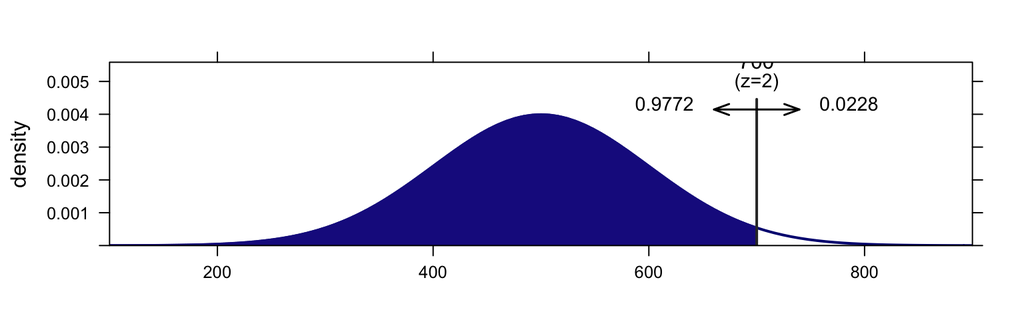

```
## [1] 0.9772
```

# xpnorm()

```r
xpnorm( c(300, 700), mean = 500, sd = 100)
```

```
##
## If X ~ N(500, 100), then
##
##  P(X <= 300) = P(Z <= -2) = 0.02275
##      P(X <= 700) = P(Z <=  2) = 0.97725
##  P(X >  300) = P(Z >  -2) = 0.97725
##      P(X >  700) = P(Z >   2) = 0.02275
```

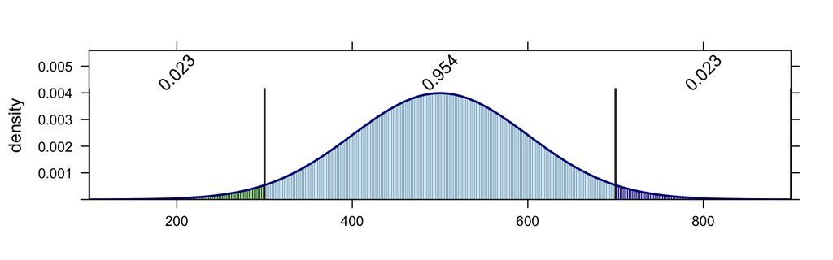

```
## [1] 0.02275 0.97725
```

# xchisq.test()

```r
xchisq.test(phs)
```

```
##
##  Pearson's Chi-squared test with Yates' continuity correction
##
## data:  x
## X-squared = 24, df = 1, p-value = 8e-07
##
##    104.00   10933.00
## (  146.52) (10890.48)
## [12.05]  [ 0.16]
## <-3.51>  < 0.41>
##
##    189.00   10845.00
## (  146.48) (10887.52)
## [12.05]  [ 0.16]
## < 3.51>  <-0.41>
##
## key:
##  observed
##  (expected)
##  [contribution to X-squared]
##  <Pearson residual>
```

# Modeling – makeFun() and plotFun()

Modeling is really the starting point for the `mosaic` design.

- linear models (`lm()` and `glm()`) defined the template
- lattice graphics use the template (so we chose lattice)
- we added functionality so numerical summaries can be done with the same template
- additional things added to make modeling easier for beginners.

# Models as Functions

```r
model <- lm(width ~ length * sex, data = KidsFeet)
Width <- makeFun(model)
Width(length = 25, sex = "B")
```

```
##     1
## 9.168
```

```r
Width(length = 25, sex = "G")
```

```
##     1
## 8.939
```

# Models as Functions – Plotting

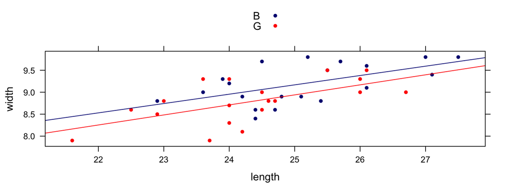

```r
xyplot( width ~ length, data = KidsFeet,
        groups = sex, auto.key = TRUE )
plotFun( Width(length, sex = "B") ~ length,
         col = 1, add = TRUE )
plotFun( Width(length, sex = "G") ~ length,
         col = 2, add = TRUE )
```

# Autoplotting (simple) models

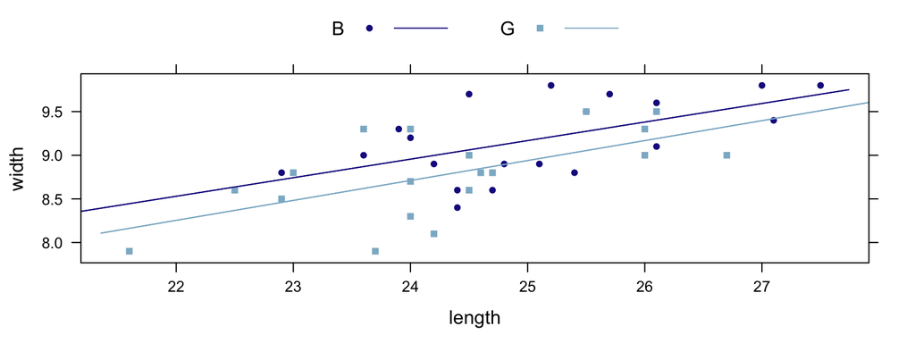

```r
plotModel(model)
```

# Simulation Based Inference

# SBI – You can do() it!

```r
do(r) * mean(~ age,       data = resample(HELPrct))
do(r) * prop(~ homeless,  data = resample(HELPrct))

do(r) * diffmean(age ~ sex,
                 data = resample(HELPrct))
do(r) * diffmean(age ~ sex,
                 data = resample(HELPrct, groups = sex))

do(r) * diffprop(homeless ~ sex,
                 data = resample(HELPrct))
do(r) * diffprop(homeless ~ sex,
                 data = resample(HELPrct, groups = sex))
```

```r
# residual resampling
Kids.lm <- lm(length ~ width * sex, data = KidsFeet)
do(r) * lm(length ~ width * sex, data = resample(Kids.lm))
```

# Lady Tasting Tea

- Often used on first day of class
- Story
- woman claims she can tell whether milk has been poured into tea or vice versa.
- Question: How do we test this claim?

# Computer Simulation

Use `rflip()` to simulate flipping coins

```r
rflip()
```

```
##
## Flipping 1 coin [ Prob(Heads) = 0.5 ] ...
##
## H
##
## Number of Heads: 1 [Proportion Heads: 1]
```

# Computer Simulation

Faster if we flip multiple coins at once:

```r
rflip(10)
```

```
##
## Flipping 10 coins [ Prob(Heads) = 0.5 ] ...
##
## H H H T T T H H H T
##
## Number of Heads: 6 [Proportion Heads: 0.6]
```

- easier to consider `heads` = correct; `tails` = incorrect than to compare with a given pattern
- this switch bothers me more than it bothers my students

# Let’s do that a lot of times

`rflip(10)` simulates 1 guessing lady tasting 10 cups.

We can do that many times to see how guessing ladies do:

```r
do(2) * rflip(10)
```

```
##    n heads tails prop
## 1 10     6     4  0.6
## 2 10     5     5  0.5
```

- `do()` is clever about what it remembers
- 2 isn’t many – we’ll do many next.

# The distribution of guessing ladies

```r
Ladies <- do(5000) * rflip(10)
head(Ladies, 1)
```

```
##    n heads tails prop
## 1 10     4     6  0.4
```

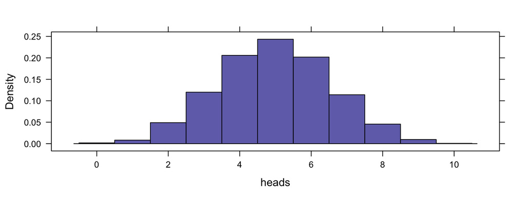

```r
histogram( ~ heads, data = Ladies, width = 1 )
```

# How often does guessing score 9 or 10?

```r
tally( ~(heads >= 9) , data = Ladies)
```

```
##
##  TRUE FALSE
##    52  4948
```

# How often does guessing score 9 or 10?

```r
tally( ~(heads >= 9) , data = Ladies)
```

```
##
##  TRUE FALSE
##    52  4948
```

```r
tally( ~(heads >= 9) , data = Ladies, format = "prop")
```

```
##
##   TRUE  FALSE
## 0.0104 0.9896
```

```r
 prop( ~(heads >= 9), data = Ladies)
```

```
##   TRUE
## 0.0104
```

# A general approach to randomization

1. Do it for your data
2. Do it for “random” data
3. Do it lots of times for “random” data
- definition of “random” is important, but can often be handled by `shuffle()` or `resample()`

# Example: Do mean ages differ by sex?

```r
diffmean(age ~ sex, data = HELPrct)
```

```
## diffmean
##  -0.7841
```

```r
do(2) * diffmean(age ~ shuffle(sex), data = HELPrct)
```

```
##   diffmean
## 1   0.1091
## 2   0.3171
```

```r
Null <-
  do(5000) * diffmean(age ~ shuffle(sex), data = HELPrct)
```

# Example: Do mean ages differ by sex?

```r
prop( ~(abs(diffmean) > 0.7841), data = Null )
```

```
##   TRUE
## 0.3616
```

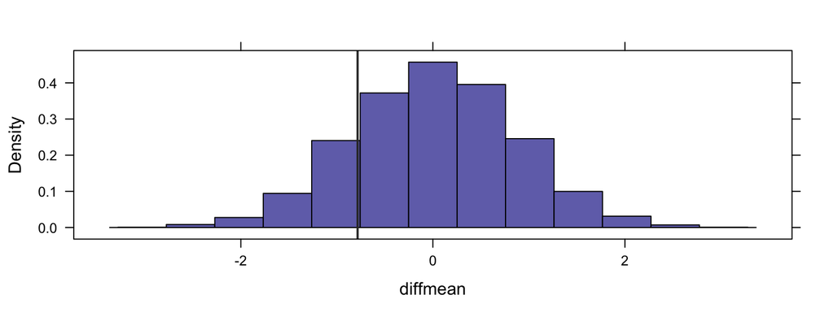

```r
histogram(~ diffmean, data = Null, v = -.7841)
```

# Example: Bootstrap

```r
Bootstrap <- do(5000) * diffmean(age~sex, data= resample(HELPrct))

       sd( ~diffmean, data = Bootstrap)
```

```
## [1] 0.8463
```

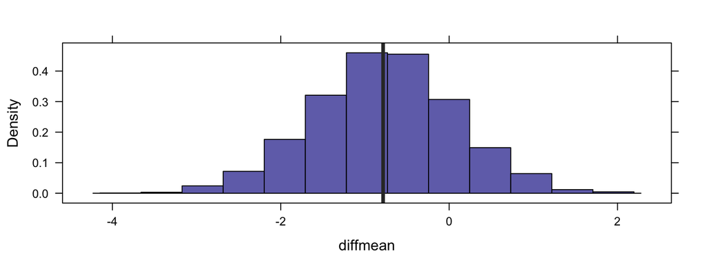

```r
histogram( ~diffmean, data = Bootstrap, v = -.7841, glwd = 4 )
```

# Example: CI for difference in mean ages

```r
cdata(~diffmean, data = Bootstrap, p = .95)
```

```
##       low        hi central.p
##   -2.4787    0.8895    0.9500
```

```r
confint(Bootstrap, method = c("quantile","se"))
```

```
##       name  lower  upper level     method estimate margin.of.error  df
## 1 diffmean -2.479 0.8895  0.95 percentile  -0.7841              NA  NA
## 2 diffmean -2.433 0.8931  0.95     stderr  -0.7841           1.663 452
```

# Randomization and linear models

```r
do(1) * lm(width ~ length, data = KidsFeet)
```

```
## Source: local data frame [1 x 9]
##
##   Intercept length  sigma r.squared     F numdf dendf  .row .index
##       (dbl)  (dbl)  (dbl)     (dbl) (dbl) (dbl) (dbl) (int)  (dbl)
## 1     2.862 0.2479 0.3963     0.411 25.82     1    37     1      1
```

```r
do(3) * lm( width ~ shuffle(length), data = KidsFeet)
```

```
## Source: local data frame [3 x 9]
##
##   Intercept    length  sigma r.squared        F numdf dendf  .row .index
##       (dbl)     (dbl)  (dbl)     (dbl)    (dbl) (dbl) (dbl) (int)  (dbl)
## 1     9.136 -0.005807 0.5164 0.0002254 0.008343     1    37     1      1
## 2     9.762 -0.031122 0.5147 0.0064752 0.241144     1    37     1      2
## 3    11.639 -0.107066 0.4962 0.0766357 3.070856     1    37     1      3
```

# Randomization and linear models

```r
do(1) * lm(width ~ length + sex, data = KidsFeet)
```

```
## Source: local data frame [1 x 10]
##
##   Intercept length    sexG  sigma r.squared     F numdf dendf  .row .index
##       (dbl)  (dbl)   (dbl)  (dbl)     (dbl) (dbl) (dbl) (dbl) (int)  (dbl)
## 1     3.641  0.221 -0.2325 0.3849    0.4595 15.31     2    36     1      1
```

```r
do(3) * lm( width ~ length + shuffle(sex), data = KidsFeet)
```

```
## Source: local data frame [3 x 10]
##
##   Intercept length    sexG  sigma r.squared     F numdf dendf  .row .index
##       (dbl)  (dbl)   (dbl)  (dbl)     (dbl) (dbl) (dbl) (dbl) (int)  (dbl)
## 1     2.524 0.2546  0.3553 0.3569    0.5353 20.74     2    36     1      1
## 2     2.835 0.2458  0.1677 0.3922    0.4388 14.07     2    36     1      2
## 3     3.078 0.2432 -0.2032 0.3877    0.4516 14.82     2    36     1      3
```

# Randomization and linear models

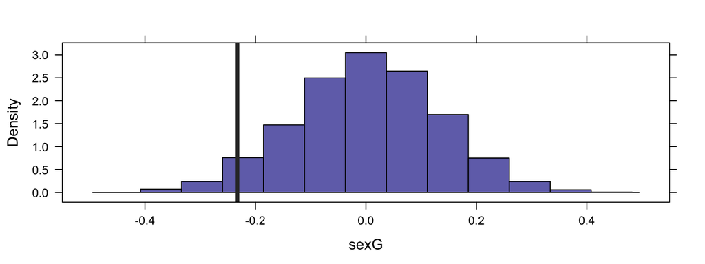

```r
Null <-
  do(5000) * lm( width ~ length + shuffle(sex), data = KidsFeet)
histogram( ~ sexG, data = Null, v = -0.2325, glwd = 4)
```

# Randomization and linear models

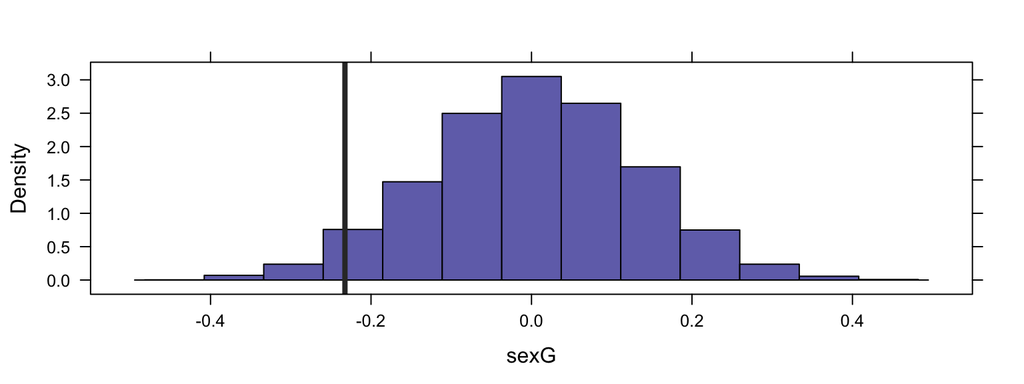

```r
histogram( ~ sexG, data = Null, v = -0.2325, glwd = 4)
```

```r
prop(~ (sexG <= -0.2325), data = Null)
```

```
##  TRUE
## 0.037
```

# Example bootstrap distributions

```r
do(r) * mean(~ age,       data = resample(HELPrct))
do(r) * prop(~ homeless,  data = resample(HELPrct))

do(r) * diffmean(age ~ sex,
                 data = resample(HELPrct))
do(r) * diffmean(age ~ sex,
                 data = resample(HELPrct, groups = sex))

do(r) * diffprop(homeless ~ sex,
                 data = resample(HELPrct))
do(r) * diffprop(homeless ~ sex,
                 data = resample(HELPrct, groups = sex))
```

# Bootstrapping Residuals

```r
Kids.lm <- lm(length ~ width * sex, data = KidsFeet)
head(resample(Kids.lm), 2)
```

```
##   length width sex
## 1  24.14   8.4   B
## 2  24.32   8.8   B
```

```r
do(2) * lm(length ~ width * sex, data = resample(Kids.lm))
```

```
## Source: local data frame [2 x 11]
##
##   Intercept width   sexG width.sexG  sigma r.squared     F numdf dendf  .row .index
##       (dbl) (dbl)  (dbl)      (dbl)  (dbl)     (dbl) (dbl) (dbl) (dbl) (int)  (dbl)
## 1    11.825 1.485 -6.949     0.7384 0.8894    0.5987  17.4     3    35     1      1
## 2     4.018 2.336 11.269    -1.3057 0.8069    0.6292  19.8     3    35     1      2
```

# Transformed Response

For a few common transformation, resample knows how to invert. The `tranformation` argument can be used to provide the transformation in other cases.

```r
Kids.lm2 <- lm(log(length) ~ width * sex, data = KidsFeet)
head(resample(Kids.lm2), 2)
```

```
##   length width sex
## 1  23.40   8.4   B
## 2  25.83   8.8   B
```

```r
do(2) * lm(log(length) ~ width * sex, data = resample(Kids.lm2))
```

```
## Source: local data frame [2 x 11]
##
##   Intercept   width    sexG width.sexG   sigma r.squared     F numdf dendf  .row .index
##       (dbl)   (dbl)   (dbl)      (dbl)   (dbl)     (dbl) (dbl) (dbl) (dbl) (int)  (dbl)
## 1     2.763 0.04997 -0.2263    0.02484 0.03884    0.4433  9.29     3    35     1      1
## 2     2.355 0.09381  0.5952   -0.06717 0.03969    0.4643 10.11     3    35     1      2
```

# A Little Goes A Long Way

# A Little Goes A Long Way

Equipped with a modest subset of R, students can be quite creative:

- The template `goal(y ~ x, data = mydata)`
- A list of goals
  - `xyplot()`, `bwplot()`, `histogram()`, etc.
  - `mean()`, `sd()`, `tally()`, `favstats()`, etc.
  - `lm()`, `glm()`
  - `t.test()`, `binom.test()`, etc.
- `do()`
- a few bells as whistles as desired.

Additional R skills can be added as needed later.

*If R is the hardest part of your course, then your R is too hard and your questions are too easy.*

# Additional Resources

# mosaic resources

- Little Books https://github.com/ProjectMOSAIC/LittleBooks
  - Start Teaching with R
  - A Student’s Guide to R
  - Start R in Calculus
- [Resources Vignette](https://github.com/ProjectMOSAIC/mosaic/blob/master/vignettes/mosaic-resources.Rmd) includes links to companion volumes to several text books.
  - *Statistics: Unlocking the Power of Data* (Lock5)
  - *Introduction to Statistical Investigations* (Tintle et al)
  - *Statistical Sleuth* (Ramsey and Shafer)
  - *Introduction to the Practice of Statistics* (Moore, McCabe, Craig)
  - *Stats: Data and Models* (De Veaux, Velleman, Bock)

# Elsewhere at eCOTS

**Tue @ 2:15 - 5:00** Breakout Sessions: *Teaching with R*

- *Technology lowering barriers: get started with R at the snap of a finger* with Mine Cetinkaya-Rundel and Nicholas Horton
- *Notebooks with R Markdown* with JJ Allaire
- *Lowering the barriers to inclusive, collaborative, reproducible analyses* with Chester Ismay and Andrew Bray

**Wed @ 2:00 - 2:45 Panel:** *Teaching with R: Free and Extendable* with JJ Allaire, Mine Cetinkaya-Rundel, Chester Ismay, and R Pruim

**Fri @ 1:30 - 2:00 BOF:** *Teaching with R and RStudio* with R Pruim and N Horton

# Elsewhere at eCOTS

### Posters

- *R-Shiny Apps to Empower a Simulation-Based Curriculum*, Allison Theobold & Jim Robison-Cox, Montana State University
- *Dynamic Data in the Classroom*, Jo Hardin, Pomona College
- *Writing about Simulations in a Theoretical Statistics Course*, Amy Wagaman, Amherst College
- *Interactive Math Stat Visualizations Using R Shiny*, Justin Post, North Carolina State University